# Rivera_Alexis_Lab4

Alexis Rivera

October 10, 2017

## Lab 4

### Part 1

The number of points scored by each team in a tournament is normally distributed, with mean μ=32 and standard deviation σ=7. What is the probability of:

#### Section a:

A team scoring 20 points or fewer? Plot the density function and shade the area.

```r
pnorm(20, mean = 32, sd=7, lower.tail = TRUE)
```

```
[1] 0.04323813
```

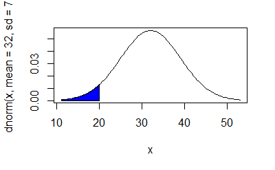

```r
curve(dnorm(x,mean = 32, sd=7),from = 11, to=53)
cord.x <- c(11,seq(11,20,0.01),20)
cord.y <- c(0,dnorm(seq(11,20,0.01),mean=32, sd = 7),0)
polygon(cord.x,cord.y,col="blue")
```

#### Section b:

A team scoring more than 35 points? Plot the density function and shade the area.

```r
pnorm(35, mean = 32, sd=7, lower.tail = FALSE)
```

```
[1] 0.3341176
```

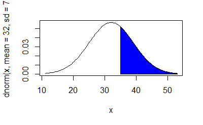

```r
curve(dnorm(x,mean = 32, sd=7),from = 11, to=53)
point.x <- c(35,seq(35,53,0.01),53)
point.y <- c(0,dnorm(seq(35,53,0.01),mean = 32, sd=7),0)
polygon(point.x,point.y,col = "blue")
```

#### Section c:

A team scoring between 20 and 40 points? Plot the density function and shade the area.

```r
pnorm(40,mean=35, sd=7)-pnorm(20, mean=32,sd=7)
```

```
[1] 0.7192366
```

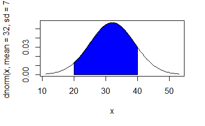

```r
curve(dnorm(x,mean=32, sd=7),from = 11, to=53)
axis.x <- c(20,seq(20,40,0.01),40)
axis.y <- c(0,dnorm(seq(20,40,0.01),mean = 32, sd=7),0)
polygon(axis.x,axis.y,col="blue")
```

### Part 2

The number of comments per cost on a social media site is exponentially distributed, with the average post receiving ten comments. What percentage of posts get:

#### Section a:

Fewer than three comments? Plot the density function and shade the area.

```r
pexp(3,rate=0.1, lower.tail = TRUE)
```

```
[1] 0.2591818
```

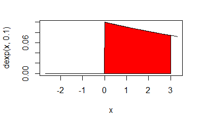

```r
curve(dexp(x,0.1), from=-2.7, to=3.3)
line.x <- c(-2.7,seq(-2.7,3,0.01),3)
line.y <- c(0,dexp(seq(-2.7,3,0.01),rate=0.1),0)
polygon(line.x,line.y,col = "red")
```

#### Section b:

More than 20 comments? Plot the density function and shade the area.

```r
pexp(20,rate=0.1,lower.tail = FALSE)
```

```
[1] 0.1353353
```

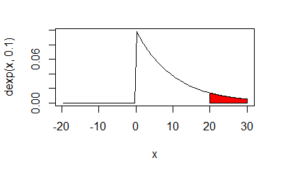

```r
curve(dexp(x,0.1),from = -19.7, to=30)
part.x <- c(20,seq(20,30,0.01),30)
part.y <- c(0,dexp(seq(20,30,0.01),rate=0.1),0)
polygon(part.x,part.y,col = "red")
```

#### Section c:

Between five and ten comments? Plot the density function and plot the area.

```r
pexp(10,rate=0.1)-pexp(5,rate=0.1)
```

```
[1] 0.2386512
```

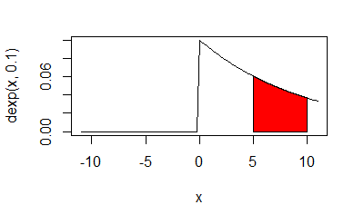

```r
curve(dexp(x,0.1),from=-11, to = 11)
x <- c(5,seq(5,10,0.01),10)
y <- c(0,dexp(seq(5,10,0.01),rate=0.1),0)
polygon(x,y,col = "red")
```

### Part 3

Basic raster creation and calculation

#### Section a:

Create a first raster (30 rows x 30 columns) and assign values to the raster based on random values from an uniform distribution. Plot the raster and histogram.

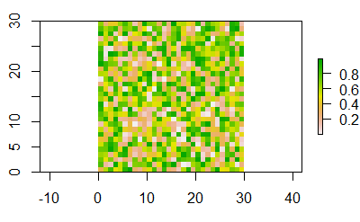

```r
library(raster)
ras <- raster(nrows=30,ncols=30,xmn=0,xmx=30,ymn=0,ymx=30)
ras[] <- runif(ncell(ras))
plot(ras)
```

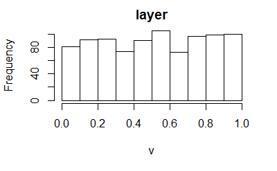

```r
hist(ras)
```

#### Section b:

Create a second raster (30 rows X 30 columns) and assign values to the raster based on random values from a normal distribution. Plot the raster and histogram.

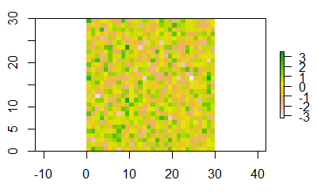

```r
ras2 <- raster(nrows=30, ncols=30, xmn=0, xmx=30, ymn=0, ymx=30)
ras2[] <- rnorm(ncell(ras2))
plot(ras2)
```

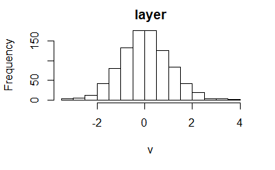

```r
hist(ras2)
```

#### Section c:

Create a third raster (30 rows X 30 columns) and assign values to the raster based on cell-by-cell addition of the first raster and the second raster. Plot the raster and histogram.

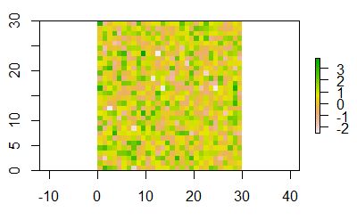

```r
ras3 <- ras+ras2
plot(ras3)
```

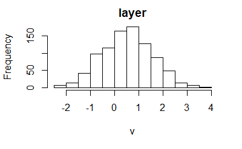

```r
hist(ras3)
```

#### Section d:

```r
cellStats(ras3,"mean")
```

```
[1] 0.5154286
```

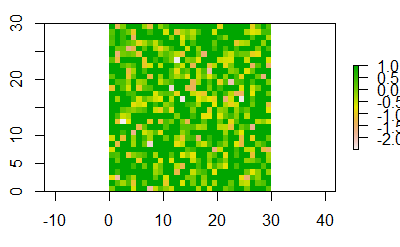

```r
ras3[ras3>0.5] <- 1
ras3[ras3==0.5] <- 0
plot(ras3)
```

```r
writeRaster(ras3,filename="Raster3.tif",overwrite=TRUE)
```